# Risk Factor Analysis

## Outcome Variable

**Outcome Variable:** haz

## Predictor Variables

**Intervention Variable:** cleanck

**Adjustment Set:**

- arm
- sex
- W_mage
- meducyrs
- feducyrs
- hhwealth_quart
- W_nrooms
- W_nhh
- W_nchldlt5
- trth2o
- impfloor
- delta_meducyrs
- delta_feducyrs
- delta_hhwealth_quart
- delta_W_nrooms
- delta_W_nhh
- delta_W_nchldlt5
- delta_trth2o
- delta_impfloor

## Stratifying Variables

The analysis was stratified on these variable(s):

- agecat
- studyid
- country

## Data Summary

| agecat | studyid | country | cleanck | n_cell | n |
| --- | --- | --- | --- | --- | --- |
| Birth | ki0047075b-MAL-ED | PERU | 1 | 1 | 2 |
| Birth | ki0047075b-MAL-ED | PERU | 0 | 1 | 2 |
| Birth | ki1000108-CMC-V-BCS-2002 | INDIA | 1 | 39 | 92 |
| Birth | ki1000108-CMC-V-BCS-2002 | INDIA | 0 | 53 | 92 |
| Birth | ki1000108-IRC | INDIA | 1 | 218 | 378 |
| Birth | ki1000108-IRC | INDIA | 0 | 160 | 378 |
| Birth | ki1017093b-PROVIDE | BANGLADESH | 1 | 438 | 539 |
| Birth | ki1017093b-PROVIDE | BANGLADESH | 0 | 101 | 539 |
| Birth | ki1017093c-NIH-Crypto | BANGLADESH | 1 | 345 | 561 |
| Birth | ki1017093c-NIH-Crypto | BANGLADESH | 0 | 216 | 561 |
| Birth | ki1113344-GMS-Nepal | NEPAL | 1 | 9 | 621 |
| Birth | ki1113344-GMS-Nepal | NEPAL | 0 | 612 | 621 |
| 6 months | ki0047075b-MAL-ED | SOUTH AFRICA | 1 | 1 | 1 |
| 6 months | ki0047075b-MAL-ED | SOUTH AFRICA | 0 | 0 | 1 |
| 6 months | ki1000108-CMC-V-BCS-2002 | INDIA | 1 | 163 | 369 |
| 6 months | ki1000108-CMC-V-BCS-2002 | INDIA | 0 | 206 | 369 |
| 6 months | ki1000108-IRC | INDIA | 1 | 230 | 398 |
| 6 months | ki1000108-IRC | INDIA | 0 | 168 | 398 |
| 6 months | ki1017093b-PROVIDE | BANGLADESH | 1 | 498 | 604 |
| 6 months | ki1017093b-PROVIDE | BANGLADESH | 0 | 106 | 604 |
| 6 months | ki1017093c-NIH-Crypto | BANGLADESH | 1 | 329 | 545 |
| 6 months | ki1017093c-NIH-Crypto | BANGLADESH | 0 | 216 | 545 |
| 6 months | ki1113344-GMS-Nepal | NEPAL | 1 | 8 | 505 |
| 6 months | ki1113344-GMS-Nepal | NEPAL | 0 | 497 | 505 |
| 24 months | ki0047075b-MAL-ED | SOUTH AFRICA | 1 | 1 | 1 |
| 24 months | ki0047075b-MAL-ED | SOUTH AFRICA | 0 | 0 | 1 |
| 24 months | ki1000108-CMC-V-BCS-2002 | INDIA | 1 | 163 | 371 |
| 24 months | ki1000108-CMC-V-BCS-2002 | INDIA | 0 | 208 | 371 |
| 24 months | ki1000108-IRC | INDIA | 1 | 231 | 400 |
| 24 months | ki1000108-IRC | INDIA | 0 | 169 | 400 |
| 24 months | ki1017093b-PROVIDE | BANGLADESH | 1 | 479 | 578 |
| 24 months | ki1017093b-PROVIDE | BANGLADESH | 0 | 99 | 578 |
| 24 months | ki1017093c-NIH-Crypto | BANGLADESH | 1 | 199 | 410 |
| 24 months | ki1017093c-NIH-Crypto | BANGLADESH | 0 | 211 | 410 |
| 24 months | ki1113344-GMS-Nepal | NEPAL | 1 | 5 | 435 |
| 24 months | ki1113344-GMS-Nepal | NEPAL | 0 | 430 | 435 |

The following strata were considered:

- agecat: 24 months, studyid: ki0047075b-MAL-ED, country: SOUTH AFRICA
- agecat: 24 months, studyid: ki1000108-CMC-V-BCS-2002, country: INDIA
- agecat: 24 months, studyid: ki1000108-IRC, country: INDIA
- agecat: 24 months, studyid: ki1017093b-PROVIDE, country: BANGLADESH
- agecat: 24 months, studyid: ki1017093c-NIH-Crypto, country: BANGLADESH
- agecat: 24 months, studyid: ki1113344-GMS-Nepal, country: NEPAL
- agecat: 6 months, studyid: ki0047075b-MAL-ED, country: SOUTH AFRICA
- agecat: 6 months, studyid: ki1000108-CMC-V-BCS-2002, country: INDIA
- agecat: 6 months, studyid: ki1000108-IRC, country: INDIA
- agecat: 6 months, studyid: ki1017093b-PROVIDE, country: BANGLADESH
- agecat: 6 months, studyid: ki1017093c-NIH-Crypto, country: BANGLADESH
- agecat: 6 months, studyid: ki1113344-GMS-Nepal, country: NEPAL
- agecat: Birth, studyid: ki0047075b-MAL-ED, country: PERU
- agecat: Birth, studyid: ki1000108-CMC-V-BCS-2002, country: INDIA
- agecat: Birth, studyid: ki1000108-IRC, country: INDIA
- agecat: Birth, studyid: ki1017093b-PROVIDE, country: BANGLADESH
- agecat: Birth, studyid: ki1017093c-NIH-Crypto, country: BANGLADESH
- agecat: Birth, studyid: ki1113344-GMS-Nepal, country: NEPAL

### Dropped Strata

Some strata were dropped due to rare outcomes:

- agecat: Birth, studyid: ki0047075b-MAL-ED, country: PERU
- agecat: 6 months, studyid: ki0047075b-MAL-ED, country: SOUTH AFRICA
- agecat: 24 months, studyid: ki0047075b-MAL-ED, country: SOUTH AFRICA

## Methods Detail

We’re interested in the causal parameters $E[Y_a]$ for all values of $a \in \mathcal{A}$. These parameters represent the mean outcome if, possibly contrary to fact, we intervened to set all units to have $A=a$. Under the randomization and positivity assumptions, these are identified by the statistical parameters $\psi_a=E_W[E_{Y|A,W}(Y|A=a,W)]$. In addition, we’re interested in the mean of $Y$, $E[Y]$ under no intervention (the observed mean). We will estimate these parameters by using SuperLearner to fit the relevant likelihood factors – $E_{Y|A,W}(Y|A=a,W)$ and $p(A=a|W)$, and then updating our likelihood fit using a joint TMLE.

For unadjusted analyses ($W=\{\}$), initial likelihoods were estimated using Lrnr_glm to estimate the simple $E(Y|A)$ and Lrnr_mean to estimate $p(A)$. For adjusted analyses, a small library containing Lrnr_glmnet, Lrnr_xgboost, and Lrnr_mean was used.

Having estimated these parameters, we will then use the delta method to estimate relative risks and attributable risks relative to a prespecified baseline level of $A$.

# Results Detail

## Results Plots

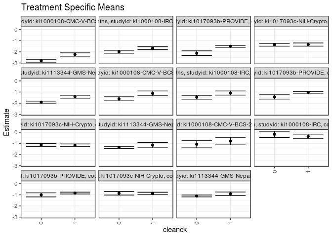

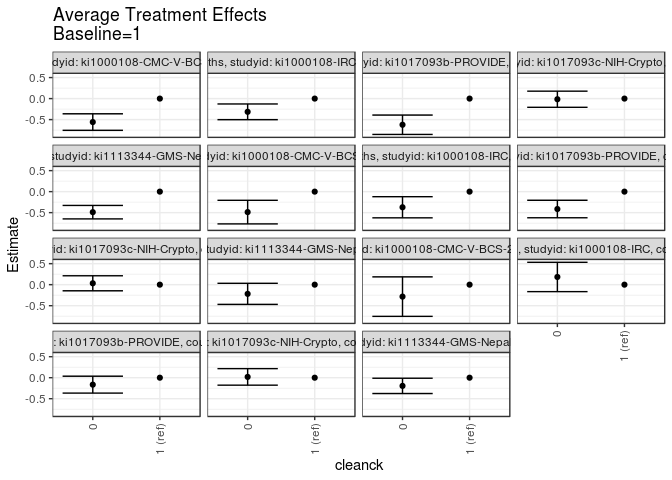

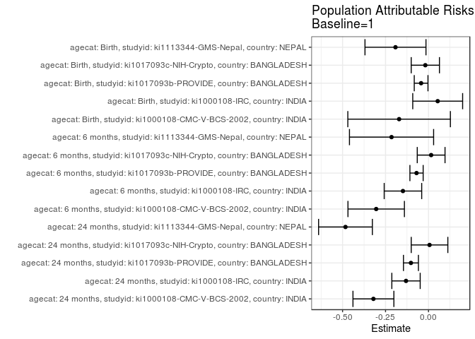

## Results Table

### Parameter: TSM

| agecat | studyid | country | intervention_level | baseline_level | estimate | ci_lower | ci_upper |
| --- | --- | --- | --- | --- | --- | --- | --- |
| Birth | ki1000108-CMC-V-BCS-2002 | INDIA | 1 | NA | -0.7902220 | -1.1276295 | -0.4528145 |
| Birth | ki1000108-CMC-V-BCS-2002 | INDIA | 0 | NA | -1.0745249 | -1.3945676 | -0.7544822 |
| Birth | ki1000108-IRC | INDIA | 1 | NA | -0.3711878 | -0.5757322 | -0.1666434 |
| Birth | ki1000108-IRC | INDIA | 0 | NA | -0.1878825 | -0.4684082 | 0.0926432 |
| Birth | ki1017093b-PROVIDE | BANGLADESH | 1 | NA | -0.8421602 | -0.9246020 | -0.7597185 |
| Birth | ki1017093b-PROVIDE | BANGLADESH | 0 | NA | -1.0073990 | -1.1889558 | -0.8258422 |
| Birth | ki1017093c-NIH-Crypto | BANGLADESH | 1 | NA | -0.8812063 | -0.9951862 | -0.7672263 |
| Birth | ki1017093c-NIH-Crypto | BANGLADESH | 0 | NA | -0.8621009 | -1.0212473 | -0.7029545 |
| Birth | ki1113344-GMS-Nepal | NEPAL | 1 | NA | -0.9077778 | -1.0681024 | -0.7474531 |
| Birth | ki1113344-GMS-Nepal | NEPAL | 0 | NA | -1.1026961 | -1.1887883 | -1.0166039 |
| 6 months | ki1000108-CMC-V-BCS-2002 | INDIA | 1 | NA | -1.1190961 | -1.3334633 | -0.9047290 |
| 6 months | ki1000108-CMC-V-BCS-2002 | INDIA | 0 | NA | -1.6060130 | -1.7867379 | -1.4252881 |
| 6 months | ki1000108-IRC | INDIA | 1 | NA | -1.0887496 | -1.2724537 | -0.9050455 |
| 6 months | ki1000108-IRC | INDIA | 0 | NA | -1.4608690 | -1.6331909 | -1.2885472 |
| 6 months | ki1017093b-PROVIDE | BANGLADESH | 1 | NA | -1.0221035 | -1.1018109 | -0.9423961 |
| 6 months | ki1017093b-PROVIDE | BANGLADESH | 0 | NA | -1.4361816 | -1.6273615 | -1.2450016 |
| 6 months | ki1017093c-NIH-Crypto | BANGLADESH | 1 | NA | -1.1636654 | -1.2818069 | -1.0455238 |
| 6 months | ki1017093c-NIH-Crypto | BANGLADESH | 0 | NA | -1.1307348 | -1.2651977 | -0.9962720 |
| 6 months | ki1113344-GMS-Nepal | NEPAL | 1 | NA | -1.1500000 | -1.3864333 | -0.9135667 |
| 6 months | ki1113344-GMS-Nepal | NEPAL | 0 | NA | -1.3684775 | -1.4530701 | -1.2838850 |
| 24 months | ki1000108-CMC-V-BCS-2002 | INDIA | 1 | NA | -2.2384178 | -2.3864948 | -2.0903408 |
| 24 months | ki1000108-CMC-V-BCS-2002 | INDIA | 0 | NA | -2.7969963 | -2.9268896 | -2.6671031 |
| 24 months | ki1000108-IRC | INDIA | 1 | NA | -1.6731955 | -1.8052132 | -1.5411778 |
| 24 months | ki1000108-IRC | INDIA | 0 | NA | -1.9878910 | -2.1195039 | -1.8562780 |
| 24 months | ki1017093b-PROVIDE | BANGLADESH | 1 | NA | -1.5002894 | -1.5877995 | -1.4127794 |
| 24 months | ki1017093b-PROVIDE | BANGLADESH | 0 | NA | -2.1228559 | -2.3359453 | -1.9097665 |
| 24 months | ki1017093c-NIH-Crypto | BANGLADESH | 1 | NA | -1.3469432 | -1.4893281 | -1.2045583 |
| 24 months | ki1017093c-NIH-Crypto | BANGLADESH | 0 | NA | -1.3624091 | -1.4906292 | -1.2341890 |
| 24 months | ki1113344-GMS-Nepal | NEPAL | 1 | NA | -1.4140000 | -1.5461204 | -1.2818796 |
| 24 months | ki1113344-GMS-Nepal | NEPAL | 0 | NA | -1.9026977 | -1.9936549 | -1.8117404 |

### Parameter: E(Y)

| agecat | studyid | country | intervention_level | baseline_level | estimate | ci_lower | ci_upper |
| --- | --- | --- | --- | --- | --- | --- | --- |
| Birth | ki1000108-CMC-V-BCS-2002 | INDIA | NA | NA | -0.9611957 | -1.1776967 | -0.7446946 |
| Birth | ki1000108-IRC | INDIA | NA | NA | -0.3176455 | -0.4788394 | -0.1564516 |
| Birth | ki1017093b-PROVIDE | BANGLADESH | NA | NA | -0.8851020 | -0.9601332 | -0.8100709 |
| Birth | ki1017093c-NIH-Crypto | BANGLADESH | NA | NA | -0.8996078 | -0.9825064 | -0.8167093 |
| Birth | ki1113344-GMS-Nepal | NEPAL | NA | NA | -1.0998712 | -1.1839267 | -1.0158156 |
| 6 months | ki1000108-CMC-V-BCS-2002 | INDIA | NA | NA | -1.4234508 | -1.5645974 | -1.2823042 |
| 6 months | ki1000108-IRC | INDIA | NA | NA | -1.2373869 | -1.3694835 | -1.1052903 |
| 6 months | ki1017093b-PROVIDE | BANGLADESH | NA | NA | -1.0916915 | -1.1661176 | -1.0172654 |
| 6 months | ki1017093c-NIH-Crypto | BANGLADESH | NA | NA | -1.1482385 | -1.2287866 | -1.0676904 |
| 6 months | ki1113344-GMS-Nepal | NEPAL | NA | NA | -1.3650165 | -1.4477401 | -1.2822929 |
| 24 months | ki1000108-CMC-V-BCS-2002 | INDIA | NA | NA | -2.5588679 | -2.6583730 | -2.4593629 |
| 24 months | ki1000108-IRC | INDIA | NA | NA | -1.8039875 | -1.8980579 | -1.7099171 |
| 24 months | ki1017093b-PROVIDE | BANGLADESH | NA | NA | -1.6024221 | -1.6857420 | -1.5191023 |
| 24 months | ki1017093c-NIH-Crypto | BANGLADESH | NA | NA | -1.3408537 | -1.4302211 | -1.2514862 |
| 24 months | ki1113344-GMS-Nepal | NEPAL | NA | NA | -1.8970805 | -1.9859605 | -1.8082004 |

### Parameter: ATE

| agecat | studyid | country | intervention_level | baseline_level | estimate | ci_lower | ci_upper |
| --- | --- | --- | --- | --- | --- | --- | --- |
| Birth | ki1000108-CMC-V-BCS-2002 | INDIA | 1 | 1 | 0.0000000 | 0.0000000 | 0.0000000 |
| Birth | ki1000108-CMC-V-BCS-2002 | INDIA | 0 | 1 | -0.2843029 | -0.7541414 | 0.1855355 |
| Birth | ki1000108-IRC | INDIA | 1 | 1 | 0.0000000 | 0.0000000 | 0.0000000 |
| Birth | ki1000108-IRC | INDIA | 0 | 1 | 0.1833053 | -0.1657339 | 0.5323445 |
| Birth | ki1017093b-PROVIDE | BANGLADESH | 1 | 1 | 0.0000000 | 0.0000000 | 0.0000000 |
| Birth | ki1017093b-PROVIDE | BANGLADESH | 0 | 1 | -0.1652388 | -0.3661245 | 0.0356470 |
| Birth | ki1017093c-NIH-Crypto | BANGLADESH | 1 | 1 | 0.0000000 | 0.0000000 | 0.0000000 |
| Birth | ki1017093c-NIH-Crypto | BANGLADESH | 0 | 1 | 0.0191054 | -0.1780336 | 0.2162443 |
| Birth | ki1113344-GMS-Nepal | NEPAL | 1 | 1 | 0.0000000 | 0.0000000 | 0.0000000 |
| Birth | ki1113344-GMS-Nepal | NEPAL | 0 | 1 | -0.1949183 | -0.3768960 | -0.0129406 |
| 6 months | ki1000108-CMC-V-BCS-2002 | INDIA | 1 | 1 | 0.0000000 | 0.0000000 | 0.0000000 |
| 6 months | ki1000108-CMC-V-BCS-2002 | INDIA | 0 | 1 | -0.4869169 | -0.7679487 | -0.2058851 |
| 6 months | ki1000108-IRC | INDIA | 1 | 1 | 0.0000000 | 0.0000000 | 0.0000000 |
| 6 months | ki1000108-IRC | INDIA | 0 | 1 | -0.3721194 | -0.6233202 | -0.1209187 |
| 6 months | ki1017093b-PROVIDE | BANGLADESH | 1 | 1 | 0.0000000 | 0.0000000 | 0.0000000 |
| 6 months | ki1017093b-PROVIDE | BANGLADESH | 0 | 1 | -0.4140781 | -0.6224206 | -0.2057355 |
| 6 months | ki1017093c-NIH-Crypto | BANGLADESH | 1 | 1 | 0.0000000 | 0.0000000 | 0.0000000 |
| 6 months | ki1017093c-NIH-Crypto | BANGLADESH | 0 | 1 | 0.0329306 | -0.1458406 | 0.2117017 |
| 6 months | ki1113344-GMS-Nepal | NEPAL | 1 | 1 | 0.0000000 | 0.0000000 | 0.0000000 |
| 6 months | ki1113344-GMS-Nepal | NEPAL | 0 | 1 | -0.2184775 | -0.4695882 | 0.0326332 |
| 24 months | ki1000108-CMC-V-BCS-2002 | INDIA | 1 | 1 | 0.0000000 | 0.0000000 | 0.0000000 |
| 24 months | ki1000108-CMC-V-BCS-2002 | INDIA | 0 | 1 | -0.5585785 | -0.7554859 | -0.3616711 |
| 24 months | ki1000108-IRC | INDIA | 1 | 1 | 0.0000000 | 0.0000000 | 0.0000000 |
| 24 months | ki1000108-IRC | INDIA | 0 | 1 | -0.3146955 | -0.5014270 | -0.1279639 |
| 24 months | ki1017093b-PROVIDE | BANGLADESH | 1 | 1 | 0.0000000 | 0.0000000 | 0.0000000 |
| 24 months | ki1017093b-PROVIDE | BANGLADESH | 0 | 1 | -0.6225665 | -0.8530696 | -0.3920633 |
| 24 months | ki1017093c-NIH-Crypto | BANGLADESH | 1 | 1 | 0.0000000 | 0.0000000 | 0.0000000 |
| 24 months | ki1017093c-NIH-Crypto | BANGLADESH | 0 | 1 | -0.0154659 | -0.2074456 | 0.1765139 |
| 24 months | ki1113344-GMS-Nepal | NEPAL | 1 | 1 | 0.0000000 | 0.0000000 | 0.0000000 |
| 24 months | ki1113344-GMS-Nepal | NEPAL | 0 | 1 | -0.4886977 | -0.6491003 | -0.3282950 |

### Parameter: PAR

| agecat | studyid | country | intervention_level | baseline_level | estimate | ci_lower | ci_upper |
| --- | --- | --- | --- | --- | --- | --- | --- |
| Birth | ki1000108-CMC-V-BCS-2002 | INDIA | 1 | NA | -0.1709737 | -0.4694430 | 0.1274957 |
| Birth | ki1000108-IRC | INDIA | 1 | NA | 0.0535423 | -0.0916077 | 0.1986923 |
| Birth | ki1017093b-PROVIDE | BANGLADESH | 1 | NA | -0.0429418 | -0.0828551 | -0.0030286 |
| Birth | ki1017093c-NIH-Crypto | BANGLADESH | 1 | NA | -0.0184016 | -0.1005296 | 0.0637264 |
| Birth | ki1113344-GMS-Nepal | NEPAL | 1 | NA | -0.1920934 | -0.3695311 | -0.0146557 |
| 6 months | ki1000108-CMC-V-BCS-2002 | INDIA | 1 | NA | -0.3043546 | -0.4685988 | -0.1401105 |
| 6 months | ki1000108-IRC | INDIA | 1 | NA | -0.1486373 | -0.2577573 | -0.0395174 |
| 6 months | ki1017093b-PROVIDE | BANGLADESH | 1 | NA | -0.0695880 | -0.1081318 | -0.0310442 |
| 6 months | ki1017093c-NIH-Crypto | BANGLADESH | 1 | NA | 0.0154268 | -0.0653700 | 0.0962237 |
| 6 months | ki1113344-GMS-Nepal | NEPAL | 1 | NA | -0.2150165 | -0.4598610 | 0.0298280 |
| 24 months | ki1000108-CMC-V-BCS-2002 | INDIA | 1 | NA | -0.3204501 | -0.4395132 | -0.2013870 |
| 24 months | ki1000108-IRC | INDIA | 1 | NA | -0.1307920 | -0.2133076 | -0.0482764 |
| 24 months | ki1017093b-PROVIDE | BANGLADESH | 1 | NA | -0.1021327 | -0.1456693 | -0.0585960 |
| 24 months | ki1017093c-NIH-Crypto | BANGLADESH | 1 | NA | 0.0060895 | -0.1004385 | 0.1126176 |
| 24 months | ki1113344-GMS-Nepal | NEPAL | 1 | NA | -0.4830805 | -0.6395498 | -0.3266111 |